# Inverse Transform Sampling

### **NOTES ON STATISTICS, PROBABILITY and MATHEMATICS**

### Inverse Integral Transform Sampling Method:

This is the answer to the [original question posted in CV](http://stats.stackexchange.com/q/169293/67822):

I can generate as many samples from one or more uniform distribution (0,1) as I wish. How can I use this to generate a beta distribution?

*ANSWER:*

I will use [R] not so much as a practical answer (`rbeta` would do the trick), but as an attempt at thinking through the probability integral transform. I hope you are familiar with the code so you can follow, or replicate (if this answers your question).

The idea behind the [Probability Integral Transform](https://en.wikipedia.org/wiki/Probability_integral_transform) is that since a $\text{cdf}$ monotonically increases in value from $0$ to $1$, applying the $\text{cdf}$ function to random values form whichever distribution we may be interested in will on aggregate generate as many results say, between $0.1$ and $0.2$ as from $0.8$ to $0.9$. Now, this is exactly what a $\text{pdf}$ of a $U(0,1)$. It follows that if we start with values from a random uniform, $U \sim (0,1)$ instead, and we apply the *inverse* $\text{cdf}$ of the distribution we are aiming at, we’ll end up with random values of that distribution.

Let’s quickly show it with the queen of the distributions… The Normal $N(0,1)$. We generate $10,000$ random values, and plug them into the $erf$ function, plotting the results:

```
# Random variable from a normal distribution:
x <- rnorm(1e4)
par(mfrow=c(1,2))
hist(x, col='skyblue', main = "Random Normal")

# When transform by obtaining the cdf (x) will give us a Uniform:
y <- pnorm(x)
hist(y, col='skyblue', main = "CDF(X)")
```

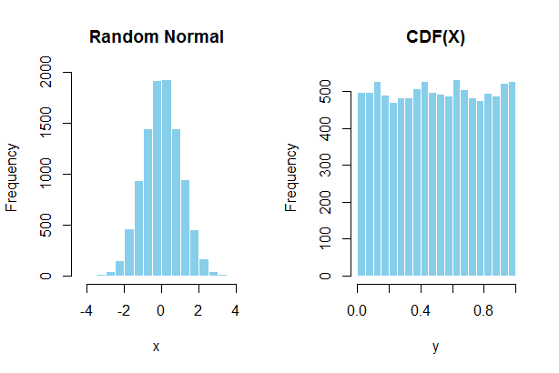

In your case, we are aiming for $X \sim Beta(\alpha, \beta)$. So let’s get started at the end and come up with $10,000$ random values from a $U(0,1)$. We also have to select values for the shape parameters of the $Beta$ distribution. We are not constrained there, so we can select for example, $\alpha=0.5$ and $\beta=0.5$. Now we are ready for the inverse, which is simply the `qbeta` function:

[output not shown]

Compare this to the shape of the $Beta(\alpha,\beta)$ $\text{pdf}$:

```
x <- seq(0, 1, 0.001)
beta_pdf <- dbeta(x, alpha, beta)
plot(beta_pdf, type ="l", col='skyblue', lwd = 3,
     main = "Beta pdf")
```

[figure not shown]

References:

[Basic Inferential Calculations with only Summary Statistics](https://stats.stackexchange.com/questions/175141/basic-inferential-calculations-with-only-summary-statistics-available/175142#175142)

[Home Page](http://rinterested.github.io/statistics/index.html)

**NOTE: These are tentative notes on different topics for personal use - expect mistakes and misunderstandings.**